# Lecture 7: Data visualization, part 2: tidyverse

- Show All Code
- Hide All Code
- View Source

Author

Affiliation

Guillem Ylla, PhD

Jagiellonian University

```r
knitr::opts_chunk$set(echo = TRUE)
library("tidyr")
library("dplyr")
library("ggplot2")
```

## Wide vs long format

### Load and observe data

```r
Table_TPMs_wide<-readr::read_csv("/home/guillem/Documents/Teaching/FBBB_UJ_AT4BR/Data/TPMs_table_100genes.csv")
```

```r
dim(Table_TPMs_wide) # table dimensions
```

```
[1] 100   7
```

```r
summary(Table_TPMs_wide) # table summary
```

```
    GeneID            Control_1         Control_2         Control_3
 Length:100         Min.   :  0.000   Min.   :  0.000   Min.   :  0.000
 Class :character   1st Qu.:  2.283   1st Qu.:  1.938   1st Qu.:  1.194
 Mode  :character   Median : 25.939   Median : 26.073   Median : 26.469
                    Mean   : 70.274   Mean   : 82.004   Mean   : 79.384
                    3rd Qu.: 87.837   3rd Qu.: 79.553   3rd Qu.: 81.941
                    Max.   :831.929   Max.   :930.058   Max.   :738.262
   Treated_1         Treated_2         Treated_3
 Min.   :  0.000   Min.   :  0.000   Min.   :  0.0000
 1st Qu.:  1.392   1st Qu.:  1.487   1st Qu.:  0.7007
 Median : 34.445   Median : 37.040   Median : 31.2919
 Mean   : 83.447   Mean   : 78.917   Mean   : 76.1701
 3rd Qu.:110.834   3rd Qu.:110.926   3rd Qu.:100.0444
 Max.   :603.564   Max.   :516.945   Max.   :581.5365
```

```r
head(Table_TPMs_wide)# first rows of the table
```

```
# A tibble: 6 × 7
  GeneID      Control_1 Control_2 Control_3 Treated_1 Treated_2 Treated_3
  <chr>           <dbl>     <dbl>     <dbl>     <dbl>     <dbl>     <dbl>
1 FBgn0000003    374.      208.       161.      72.2     115.       54.4
2 FBgn0000008     11.9      10.5       14.2      8.53     10.7       4.64
3 FBgn0000014      6.40     69.4      127.     109.       92.7     179.
4 FBgn0000015     14.9       9.17      11.5      2.10      1.48      5.22
5 FBgn0000017     25.2      24.4       27.4     33.3      36.9      21.4
6 FBgn0000018     46.1      35.7       28.9     49.8      58.3      36.8
```

### Transform from wide to long

Let’s make it to long format with the **`tidyr`** function `pivot_longer()`.

```r
Table_TPMs_long<-pivot_longer(data=Table_TPMs_wide,
                             cols=colnames(Table_TPMs_wide)[-1],# Cols to pivot: all except 1st
                             values_to = "TPMs",# name of the col that contained the vals of pivoted cols
                             names_to = "Sample")# name of the col that contains the names of the pivoted cols

Table_TPMs_long
```

```
# A tibble: 600 × 3
   GeneID      Sample      TPMs
   <chr>       <chr>      <dbl>
 1 FBgn0000003 Control_1 374.
 2 FBgn0000003 Control_2 208.
 3 FBgn0000003 Control_3 161.
 4 FBgn0000003 Treated_1  72.2
 5 FBgn0000003 Treated_2 115.
 6 FBgn0000003 Treated_3  54.4
 7 FBgn0000008 Control_1  11.9
 8 FBgn0000008 Control_2  10.5
 9 FBgn0000008 Control_3  14.2
10 FBgn0000008 Treated_1   8.53
# ℹ 590 more rows
```

Now that we have in long format, we can split the Sample column into new columns with the Condition and replicate number.

```r
Table_TPMs_long_2<-Table_TPMs_long %>%
                        tidyr::separate(Sample, sep="_", into = c("Condition","Replicate"),remove=FALSE)

Table_TPMs_long_2
```

```
# A tibble: 600 × 5
   GeneID      Sample    Condition Replicate   TPMs
   <chr>       <chr>     <chr>     <chr>      <dbl>
 1 FBgn0000003 Control_1 Control   1         374.
 2 FBgn0000003 Control_2 Control   2         208.
 3 FBgn0000003 Control_3 Control   3         161.
 4 FBgn0000003 Treated_1 Treated   1          72.2
 5 FBgn0000003 Treated_2 Treated   2         115.
 6 FBgn0000003 Treated_3 Treated   3          54.4
 7 FBgn0000008 Control_1 Control   1          11.9
 8 FBgn0000008 Control_2 Control   2          10.5
 9 FBgn0000008 Control_3 Control   3          14.2
10 FBgn0000008 Treated_1 Treated   1           8.53
# ℹ 590 more rows
```

## First steps with ggplots

Initialize the plot, with the data, and the mapping of X and Y variables.

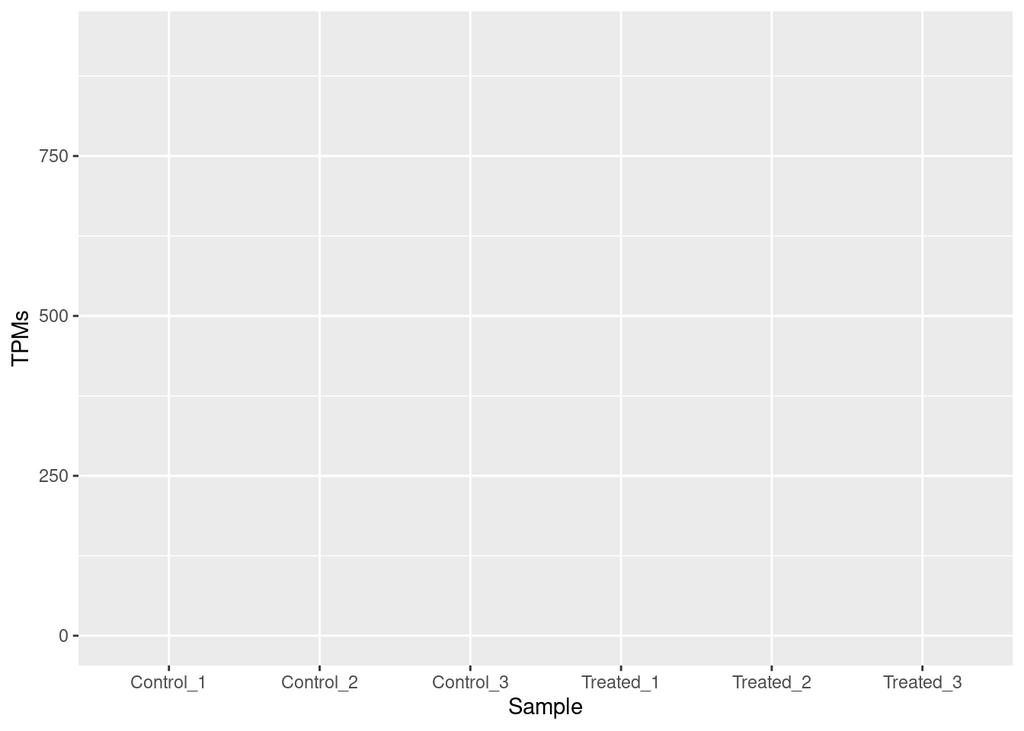

```r
p<-ggplot(data = Table_TPMs_long_2, aes(x=Sample, y=TPMs))

p
```

### Scatter plot

Let’s make a scatter plot. For each sample,w e want to see the expression of each gene as a dot:

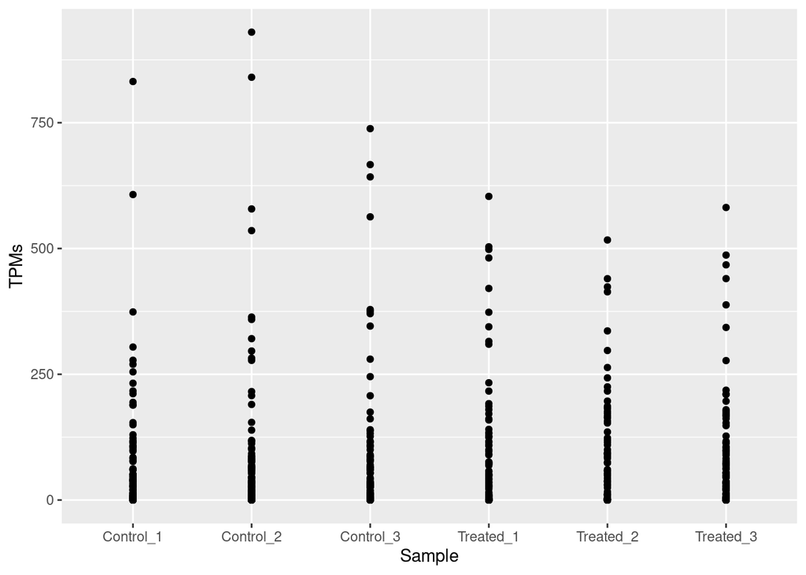

```r
p+geom_point()
```

We can spread the points horizontally withint to reduce overlaps.

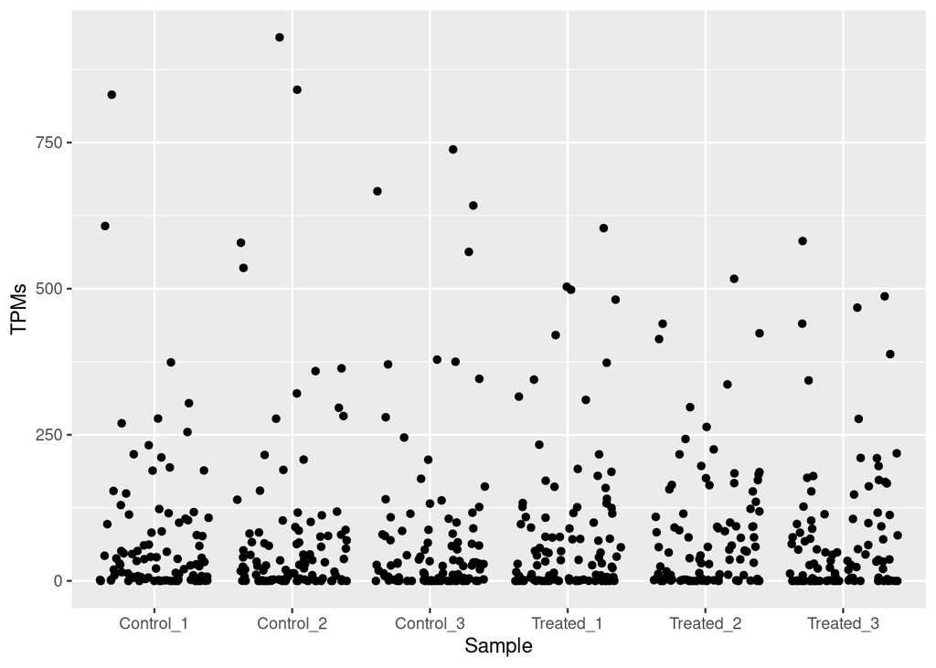

```r
p+geom_point( position = position_jitter())
```

### Boxplot

Let’s modify colors of outliers:

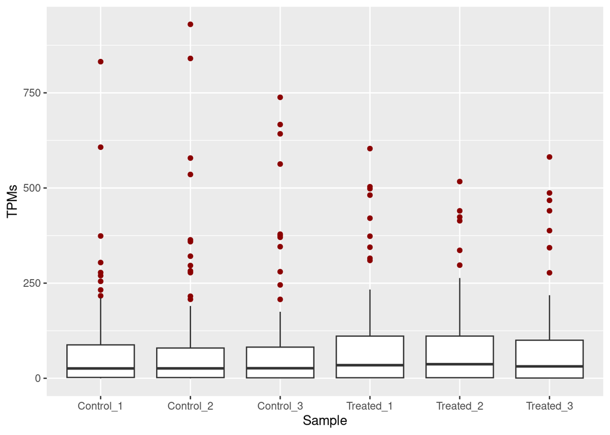

```r
ggplot(data = Table_TPMs_long_2, aes(x=Sample, y=TPMs))+
  geom_boxplot(outlier.colour ="darkred")
```

We can now fill boxes based on condition, fort which we need to **map** variable Condition to filling color with `aes()`. - Note that options outside `aes()` are global to the layer, and inside `aes()` are mapped to data.

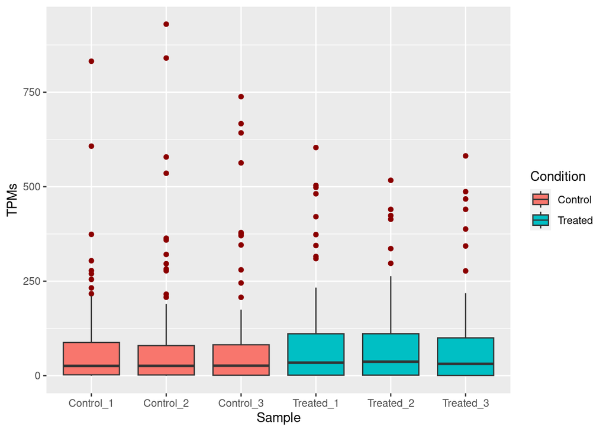

```r
ggplot(data = Table_TPMs_long_2, aes(x=Sample, y=TPMs))+
  geom_boxplot(outlier.colour ="darkred", aes(fill=Condition))
```

### Overlap boxplot and scatter plot

We will overlap scatter plot and box plot layers in 1 plot, and apply following visual changes: 1- We will color the points by condition. 2- Color boxes by replicate. 3- Hide the boxplot outlier dots. 4- Apply transparency (alpha) of 50% to all the boxplot layer.

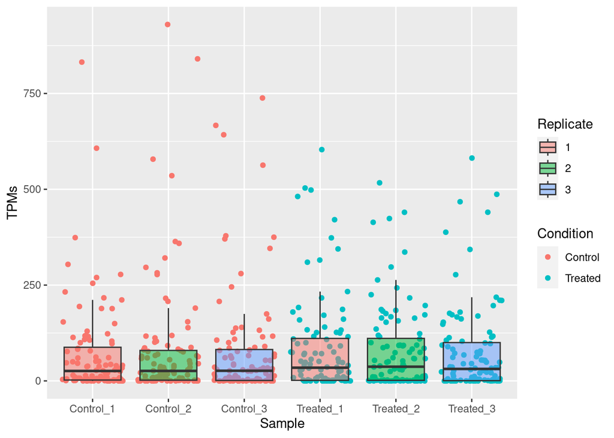

```r
ggplot(data = Table_TPMs_long_2, aes(x=Sample, y=TPMs))+
  geom_point( position = position_jitter(), aes(color=Condition))+  # scatter plot, colored by
  geom_boxplot(outlier.colour ="darkred", aes(fill=Replicate), alpha=0.5, outlier.shape = NA)
```

### Density plot

Let’s go back to a most basic chart structure. This time with a density plot, of TPM distribution.

Note that all samples are merged in a single distribution.

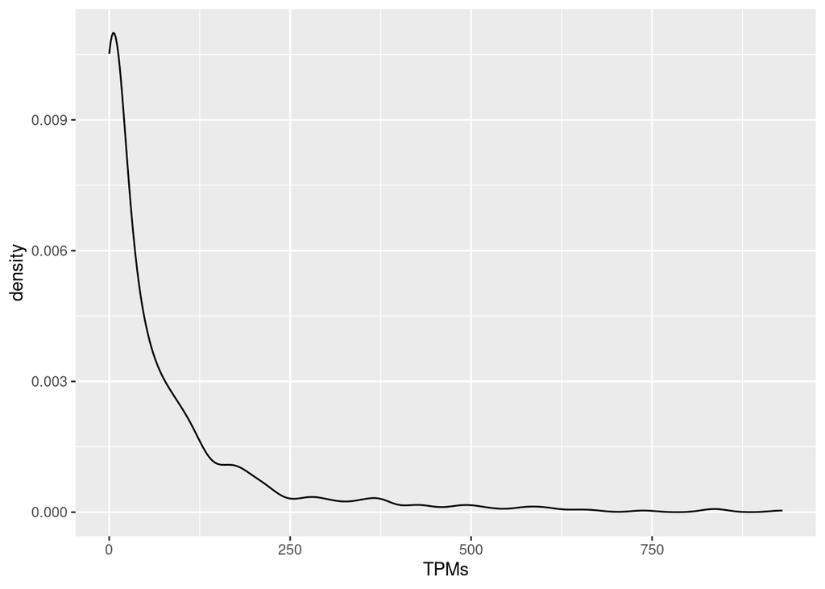

```r
ggplot(data = Table_TPMs_long_2, aes(x=TPMs))+
  geom_density()
```

#### One curve per sample

In the mapping `aes()` we can indicate that data should be “group” by “Sample”, and will plot 1 line per sample.

Is worth noting that each `geom_` function has an internal “stat”option that can perform operations in data, in this case, for example to compute the kernel density.

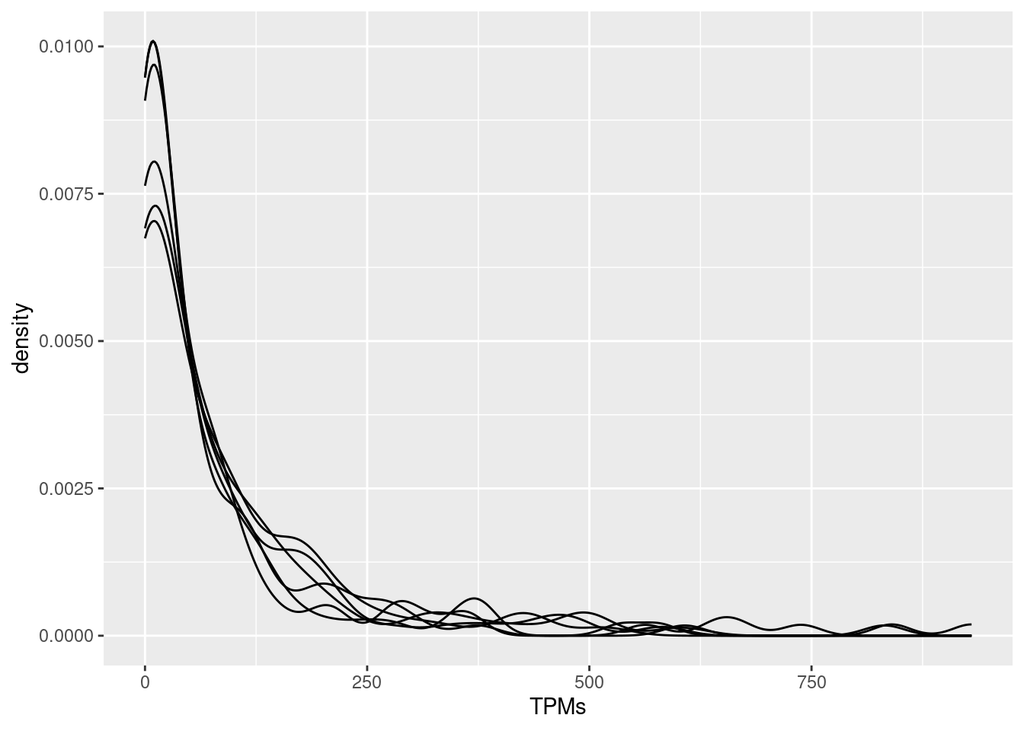

```r
ggplot(data = Table_TPMs_long_2, aes(x=TPMs, group=Sample))+
  geom_density(stat = "density")
```

If instead of “group”, we use “color”, each line will get different color.

Note that we can either put the group/fill in `aes()` in the main `ggplot()`, as well as inside the `geom_` function. If applied at the main `ggplo()` will apply to all layers unless specified differently, other-ways applies to the specific layer only

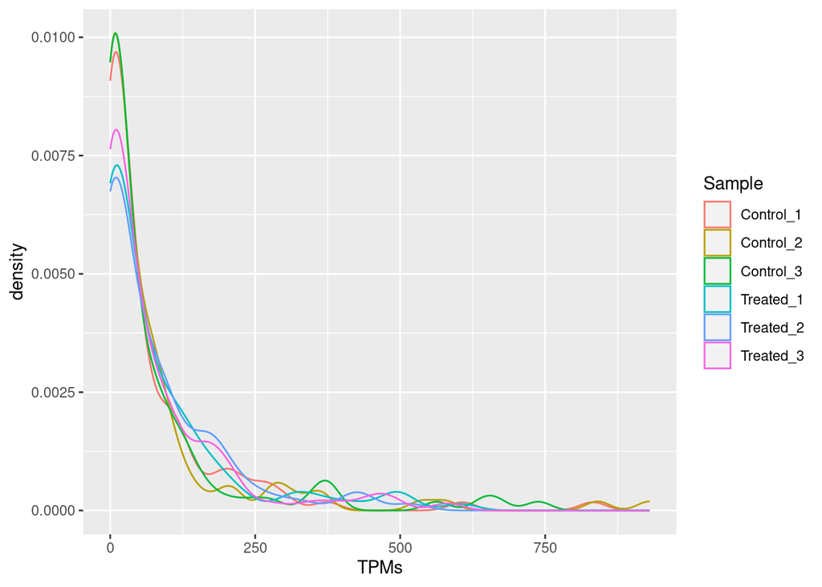

```r
ggplot(data = Table_TPMs_long_2, aes(x=TPMs))+
  geom_density(aes(color=Sample)) # now color mapping is inside geom
```

## Barplots

For barplots, we use the function `geom_bar` . By default, geom bar implements the function `stat=ount`, and plots number of observations for each X category. In this case, all samples ave 100 genes.

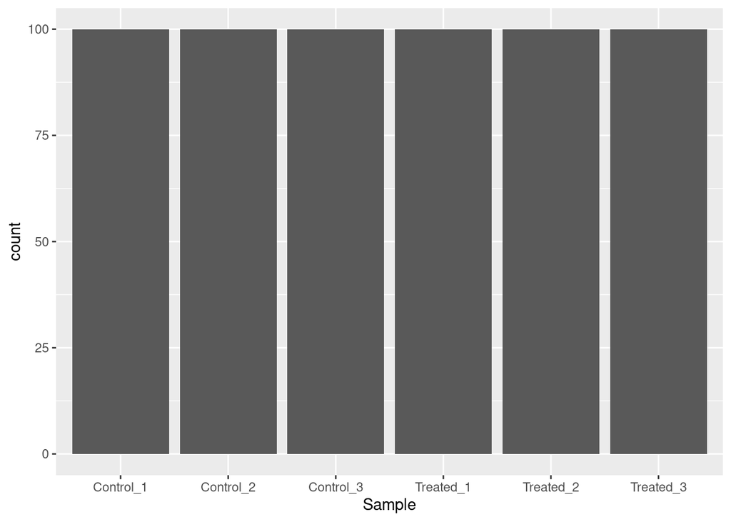

```r
 ggplot(data = Table_TPMs_long_2, aes(x=Sample))+
  geom_bar()# same as stat="count".
```

As we mentioned, `geom_` can do some calculations. In this case, for example, we want to calculate the mean of TPMs per sample, and plot it as barplot.

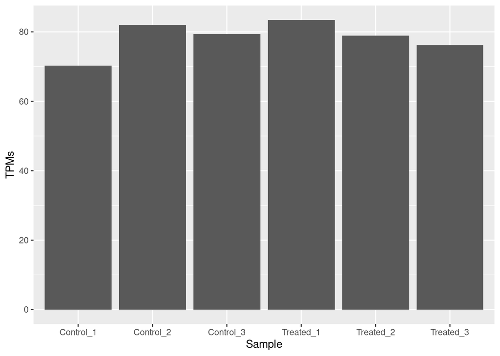

```r
 ggplot(data = Table_TPMs_long_2, aes(x=Sample))+
  geom_bar(aes(y=TPMs),stat = "summary", fun = "mean")
```

Imagine we want to group the means by Replicate, and fill by condition.

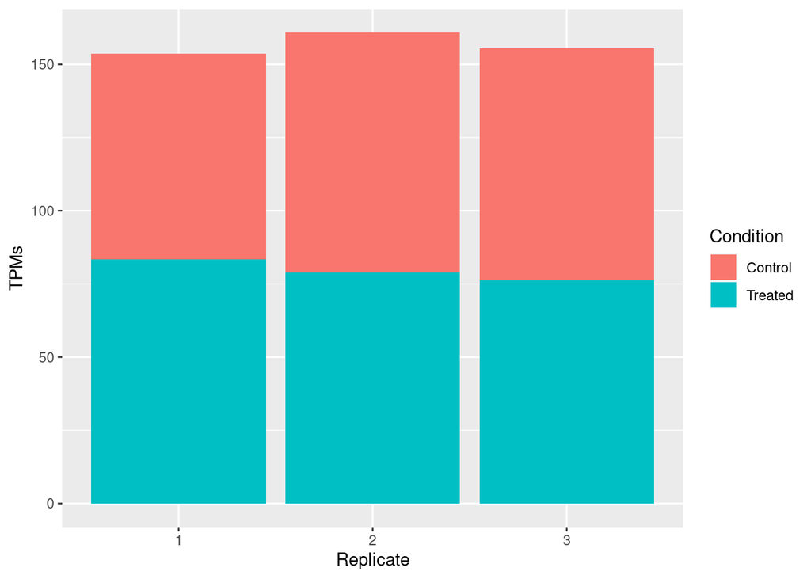

```r
 ggplot(data = Table_TPMs_long_2, aes(x=Replicate, fill=Condition))+
  geom_bar(aes(y=TPMs),stat = "summary", fun = "mean")
```

Stack bars are difficult to interpret, we can change the position with `position` function inside `geom_`.

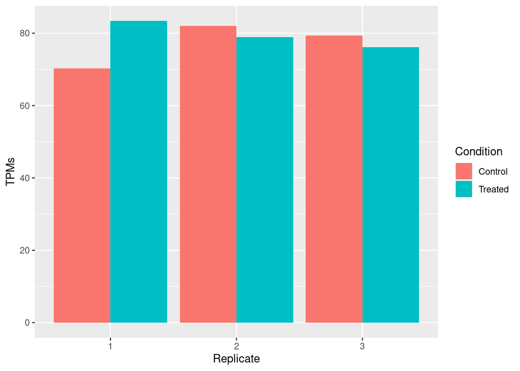

```r
 ggplot(data = Table_TPMs_long_2, aes(x=Replicate, fill=Condition))+
  geom_bar(aes(y=TPMs),stat = "summary", fun = "mean", position = "dodge")
```

## Data manipulation before plotting

Instead of allowing ggplot to do calculation, is often more clear and transparent (and help to avoid errors) to first calculate the numbers ourselves and then use ggplot only for plotting.

Let’s calculate the means per group using tidyverse tools (dplyr package)

```r
Sample_mean_TPMs<-Table_TPMs_long_2 %>% #  pipe concatenated commands (Ctrl+shift+M)
  group_by(Sample) %>% # group data by sample
  summarise(meanTPMs=mean(TPMs)) # summarise would apply functions to each group and add it as new column

Sample_mean_TPMs
```

```
# A tibble: 6 × 2
  Sample    meanTPMs
  <chr>        <dbl>
1 Control_1     70.3
2 Control_2     82.0
3 Control_3     79.4
4 Treated_1     83.4
5 Treated_2     78.9
6 Treated_3     76.2
```

Now, to plot it, we will need to indicate `geom_bar()` that we don’t want to amply any calculation, just use the given values with `stat="identity"`. This is the same as the new function `geom_col()`

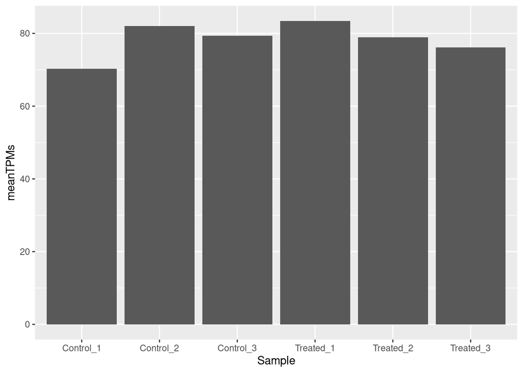

```r
ggplot(Sample_mean_TPMs, aes(x=Sample, y=meanTPMs))+
    geom_bar(stat="identity") # same as geom_col()
```

Let’s do more complicated computations, such as counting the proportion of genes with > 10 TPMs per sample.

- Let’s start creating contingency table, with the number of genes that >10 TPMs in each condition. First we group with `group_by` and then with `summarise` we apply a function to count genes in each group with `n()` and we asign it to a new column called “Numgenes”.

```r
Table_TPMs_long_2 %>%
    group_by(Sample, TPMs>10) %>%
   summarise(Numgenes=n())
```

```
# A tibble: 12 × 3
# Groups:   Sample [6]
   Sample    `TPMs > 10` Numgenes
   <chr>     <lgl>          <int>
 1 Control_1 FALSE             42
 2 Control_1 TRUE              58
 3 Control_2 FALSE             39
 4 Control_2 TRUE              61
 5 Control_3 FALSE             39
 6 Control_3 TRUE              61
 7 Treated_1 FALSE             39
 8 Treated_1 TRUE              61
 9 Treated_2 FALSE             38
10 Treated_2 TRUE              62
11 Treated_3 FALSE             39
12 Treated_3 TRUE              61
```

Now I create a new column with `mutate` , in which I divide the “Numgenes” by the `sum()` in each group (because we are still inside the grouping effect),

```r
Table_TPMs_long_2 %>%
    group_by(Sample, TPMs>10) %>%
    summarise(Numgenes=n()) %>%
    mutate(prop=Numgenes/sum(Numgenes))
```

```
# A tibble: 12 × 4
# Groups:   Sample [6]
   Sample    `TPMs > 10` Numgenes  prop
   <chr>     <lgl>          <int> <dbl>
 1 Control_1 FALSE             42  0.42
 2 Control_1 TRUE              58  0.58
 3 Control_2 FALSE             39  0.39
 4 Control_2 TRUE              61  0.61
 5 Control_3 FALSE             39  0.39
 6 Control_3 TRUE              61  0.61
 7 Treated_1 FALSE             39  0.39
 8 Treated_1 TRUE              61  0.61
 9 Treated_2 FALSE             38  0.38
10 Treated_2 TRUE              62  0.62
11 Treated_3 FALSE             39  0.39
12 Treated_3 TRUE              61  0.61
```

We can pipe this into ggplots

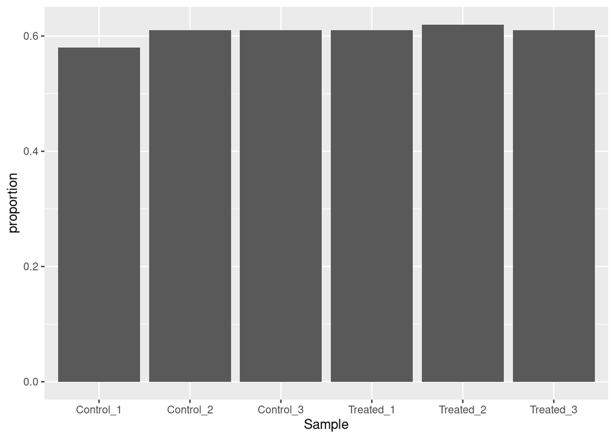

```r
Table_TPMs_long_2 %>%
    group_by(Sample, TPMs>10) %>%
    summarise(Numgenes=n()) %>%
    mutate(proportion=Numgenes/sum(Numgenes)) %>%
    filter(`TPMs > 10`==TRUE) %>% # I fitler only the rows that contain propof genes with >10TPMs
        ggplot(data = . , aes(x=Sample, y=proportion))+# using ., ggplot will use as data what is piped to it
        geom_bar(stat="identity")
```

## Axes

## Labels and annotation

## Facets

## Making plots aesthetic

### Themes

### Colors

### Palettes

### Shapes

## Saving plots

### Format

### Size

## Plotly

## More examples

### Linear Model Fit

```r
data(mtcars)
head(mtcars)
```

```
                   mpg cyl disp  hp drat    wt  qsec vs am gear carb
Mazda RX4         21.0   6  160 110 3.90 2.620 16.46  0  1    4    4
Mazda RX4 Wag     21.0   6  160 110 3.90 2.875 17.02  0  1    4    4
Datsun 710        22.8   4  108  93 3.85 2.320 18.61  1  1    4    1
Hornet 4 Drive    21.4   6  258 110 3.08 3.215 19.44  1  0    3    1
Hornet Sportabout 18.7   8  360 175 3.15 3.440 17.02  0  0    3    2
Valiant           18.1   6  225 105 2.76 3.460 20.22  1  0    3    1
```

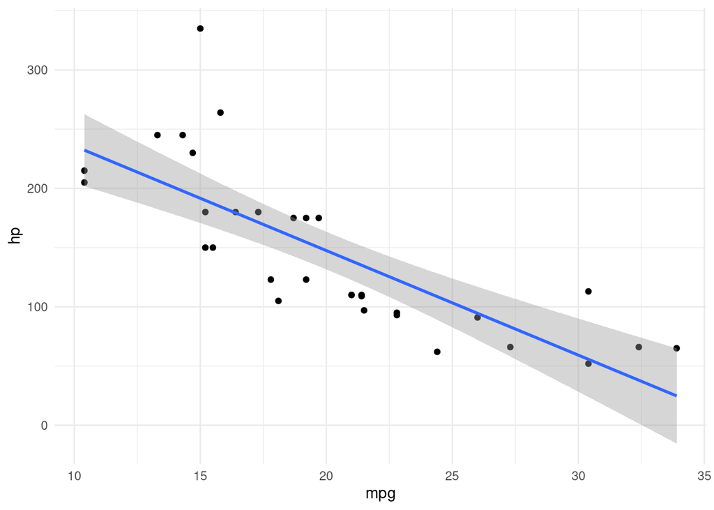

```r
ggplot(data = mtcars, aes(x = mpg, y = hp)) +
  geom_point() +
  geom_smooth(method = "lm")+
  theme_minimal()
```